# Week 4 Lectures

Mathew Merryweather

30 July 2015

#### The Str Function

A diagnostic function, alternative to `summary` Compactly display lists. One line per basic object. “Whats in this object?”

```r
str(str)
```

```
## function (object, ...)
```

```r
str(lm)
```

```
## function (formula, data, subset, weights, na.action, method = "qr",
##     model = TRUE, x = FALSE, y = FALSE, qr = TRUE, singular.ok = TRUE,
##     contrasts = NULL, offset, ...)
```

```r
x = rnorm(100,2,4)
summary(x)
```

```
##    Min. 1st Qu.  Median    Mean 3rd Qu.    Max.
##  -8.641  -0.700   1.866   2.283   5.459   9.879
```

```r
str(x)
```

```
##  num [1:100] 6.1 -2.502 1.502 -0.877 1.509 ...
```

```r
#Factor variable
f = gl(40,10)
str(f)
```

```
##  Factor w/ 40 levels "1","2","3","4",..: 1 1 1 1 1 1 1 1 1 1 ...
```

```r
library(datasets)
head(airquality)
```

```
##   Ozone Solar.R Wind Temp Month Day
## 1    41     190  7.4   67     5   1
## 2    36     118  8.0   72     5   2
## 3    12     149 12.6   74     5   3
## 4    18     313 11.5   62     5   4
## 5    NA      NA 14.3   56     5   5
## 6    28      NA 14.9   66     5   6
```

```r
str(airquality)
```

```
## 'data.frame':    153 obs. of  6 variables:
##  $ Ozone  : int  41 36 12 18 NA 28 23 19 8 NA ...
##  $ Solar.R: int  190 118 149 313 NA NA 299 99 19 194 ...
##  $ Wind   : num  7.4 8 12.6 11.5 14.3 14.9 8.6 13.8 20.1 8.6 ...
##  $ Temp   : int  67 72 74 62 56 66 65 59 61 69 ...
##  $ Month  : int  5 5 5 5 5 5 5 5 5 5 ...
##  $ Day    : int  1 2 3 4 5 6 7 8 9 10 ...
```

```r
m  = matrix(rnorm(100),10,10)
str(m)
```

```
##  num [1:10, 1:10] 0.9859 -0.2983 0.0871 0.7819 0.2586 ...
```

```r
s = split(airquality, airquality$Month)
str(s)
```

```
## List of 5
##  $ 5:'data.frame':   31 obs. of  6 variables:
##   ..$ Ozone  : int [1:31] 41 36 12 18 NA 28 23 19 8 NA ...
##   ..$ Solar.R: int [1:31] 190 118 149 313 NA NA 299 99 19 194 ...
##   ..$ Wind   : num [1:31] 7.4 8 12.6 11.5 14.3 14.9 8.6 13.8 20.1 8.6 ...
##   ..$ Temp   : int [1:31] 67 72 74 62 56 66 65 59 61 69 ...
##   ..$ Month  : int [1:31] 5 5 5 5 5 5 5 5 5 5 ...
##   ..$ Day    : int [1:31] 1 2 3 4 5 6 7 8 9 10 ...
##  $ 6:'data.frame':   30 obs. of  6 variables:
##   ..$ Ozone  : int [1:30] NA NA NA NA NA NA 29 NA 71 39 ...
##   ..$ Solar.R: int [1:30] 286 287 242 186 220 264 127 273 291 323 ...
##   ..$ Wind   : num [1:30] 8.6 9.7 16.1 9.2 8.6 14.3 9.7 6.9 13.8 11.5 ...
##   ..$ Temp   : int [1:30] 78 74 67 84 85 79 82 87 90 87 ...
##   ..$ Month  : int [1:30] 6 6 6 6 6 6 6 6 6 6 ...
##   ..$ Day    : int [1:30] 1 2 3 4 5 6 7 8 9 10 ...
##  $ 7:'data.frame':   31 obs. of  6 variables:
##   ..$ Ozone  : int [1:31] 135 49 32 NA 64 40 77 97 97 85 ...
##   ..$ Solar.R: int [1:31] 269 248 236 101 175 314 276 267 272 175 ...
##   ..$ Wind   : num [1:31] 4.1 9.2 9.2 10.9 4.6 10.9 5.1 6.3 5.7 7.4 ...
##   ..$ Temp   : int [1:31] 84 85 81 84 83 83 88 92 92 89 ...
##   ..$ Month  : int [1:31] 7 7 7 7 7 7 7 7 7 7 ...
##   ..$ Day    : int [1:31] 1 2 3 4 5 6 7 8 9 10 ...
##  $ 8:'data.frame':   31 obs. of  6 variables:
##   ..$ Ozone  : int [1:31] 39 9 16 78 35 66 122 89 110 NA ...
##   ..$ Solar.R: int [1:31] 83 24 77 NA NA NA 255 229 207 222 ...
##   ..$ Wind   : num [1:31] 6.9 13.8 7.4 6.9 7.4 4.6 4 10.3 8 8.6 ...
##   ..$ Temp   : int [1:31] 81 81 82 86 85 87 89 90 90 92 ...
##   ..$ Month  : int [1:31] 8 8 8 8 8 8 8 8 8 8 ...
##   ..$ Day    : int [1:31] 1 2 3 4 5 6 7 8 9 10 ...
##  $ 9:'data.frame':   30 obs. of  6 variables:
##   ..$ Ozone  : int [1:30] 96 78 73 91 47 32 20 23 21 24 ...
##   ..$ Solar.R: int [1:30] 167 197 183 189 95 92 252 220 230 259 ...
##   ..$ Wind   : num [1:30] 6.9 5.1 2.8 4.6 7.4 15.5 10.9 10.3 10.9 9.7 ...
##   ..$ Temp   : int [1:30] 91 92 93 93 87 84 80 78 75 73 ...
##   ..$ Month  : int [1:30] 9 9 9 9 9 9 9 9 9 9 ...
##   ..$ Day    : int [1:30] 1 2 3 4 5 6 7 8 9 10 ...
```

## Simulation

#### Generating Random Numbers

functions for probability distributions in R

- `rnorm`: Generate random Normal variates with a given mean and standard of deviation
- `dnorm`: evaluate the normal probability density (with a given mean/SD) at a point (or a vector of points)
- `pnorm`: evaluate the cumulative distribution function for a normal distribution
- `rpois`: Generate random Poisson variates with a given rate (integers)

PDFs usually have four functions associated with them

- `d` for density
- `r` for random number generation
- `p` for cumulative distribution
- `q` for quantile functions

i.e. `dgamma`, `pgamma` etc.

All require mean and SD, if none provided then Standard Distribution

```r
#Often need log of density
dnorm(x, mean = 0, sd = 1, log = FALSE)
#Also log scale option
#Lower tail = Left,
#Lower.Tail = False = right side
pnorm(q, mean = 0, sd = 1, lower.tail = TRUE, log.p = FALSE)
qnorm(p, mean = 0, sd = 1, lower.tail = TRUE, log.p = FALSE)
rnorm(n, mean = 0, sd = 1)
```

if $\Phi$ is the CDF for a standard normal distribution, then `pnorm(q)` = $\Phi$`(q)` and `qnorm(p)` = $\Phi^-1$ `(p)`.

```r
#ALWAY SET SEED!!!
set.seed(1)
x = rnorm(10)
x
```

```
##  [1] -0.6264538  0.1836433 -0.8356286  1.5952808  0.3295078 -0.8204684
##  [7]  0.4874291  0.7383247  0.5757814 -0.3053884
```

```r
x = rnorm(10, 20,2)
x
```

```
##  [1] 23.02356 20.77969 18.75752 15.57060 22.24986 19.91013 19.96762
##  [8] 21.88767 21.64244 21.18780
```

```r
summary(x)
```

```
##    Min. 1st Qu.  Median    Mean 3rd Qu.    Max.
##   15.57   19.92   20.98   20.50   21.83   23.02
```

Always use the `set.seed` function to ensure reproducibility

```r
set.seed(1)
rnorm(5)
```

```
## [1] -0.6264538  0.1836433 -0.8356286  1.5952808  0.3295078
```

```r
rnorm(5)
```

```
## [1] -0.8204684  0.4874291  0.7383247  0.5757814 -0.3053884
```

```r
set.seed(1)
rnorm(5)
```

```
## [1] -0.6264538  0.1836433 -0.8356286  1.5952808  0.3295078
```

Generating Poisson Data

```r
rpois(10,1)
```

```
##  [1] 0 0 1 1 2 1 1 4 1 2
```

```r
rpois(10,2)
```

```
##  [1] 4 1 2 0 1 1 0 1 4 1
```

```r
rpois(10,20)
```

```
##  [1] 19 19 24 23 22 24 23 20 11 22
```

```r
# Mean = Rate

# Probability that a poisson value is less than 2 when I have a rate of 2?
# Use Cumulative distribution
ppois(2,2) ## Pr(x <= 2)
```

```
## [1] 0.6766764
```

```r
ppois(4,2) ## Pr(x <= 4)
```

```
## [1] 0.947347
```

```r
ppois(6,2) ## Pr(x <= 6)
```

```
## [1] 0.9954662
```

#### Simulating a linear model

Suppose we want to simulate from the following Linear Model $y = \beta_{0} + \beta_{1}x + \epsilon$

Where $\epsilon \sim \mathcal{N} (0,2^2)$ Assume $x \sim \mathcal{N} (0,1^{2})$, $\beta_{0} = 0.5$ and $\beta_{1} = 2$

```r
# Important
set.seed(20)
# Predictor
x = rnorm(100)
# Errpr
e = rnorm(100,0,2)
# Output
y = 0.5 + 2 * x + e
summary(y)
```

```
##    Min. 1st Qu.  Median    Mean 3rd Qu.    Max.
## -6.4080 -1.5400  0.6789  0.6893  2.9300  6.5050
```

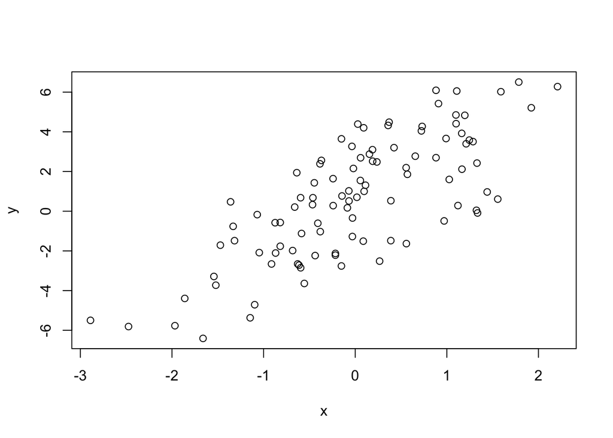

```r
plot(x,y)
```

what if `x` is a binary? perhaps gender or taken medication vs not?

```r
set.seed(10)
# 100 variables, size and probability
# i.e Male vs Female
x= rbinom(100,1,0.5)
e = rnorm(100,0,2)
y = 0.5 + 2 * x + e
summary(y)
```

```
##    Min. 1st Qu.  Median    Mean 3rd Qu.    Max.
## -3.4940 -0.1409  1.5770  1.4320  2.8400  6.9410
```

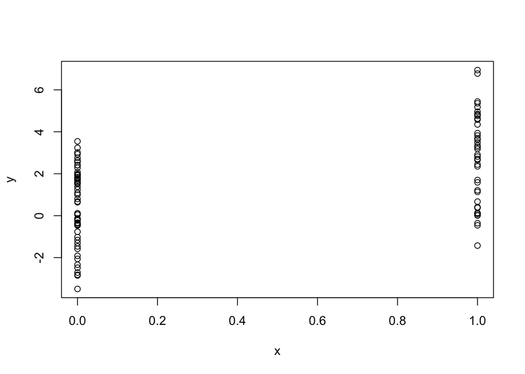

```r
plot(x,y)
```

Suppose we want to simulate from a Poisson model where

$Y \sim Poisson(\mu)$

$log(\mu) = \beta_{0} + \beta_{1}x$

and $\beta_{0} = 0.5$ and $\beta_{1} = 0.3$

```r
set.seed(1)
# Outcome variables for count data
# Error distribution is now a Poisson

#Predictor
x= rnorm(100)
#Linear Predictor
log.mu = 0.5 + 0.3 * x
#To get mean, we need exponent of log.mu
y = rpois(100,exp(log.mu))

summary(y)
```

```
##    Min. 1st Qu.  Median    Mean 3rd Qu.    Max.
##    0.00    1.00    1.00    1.55    2.00    6.00
```

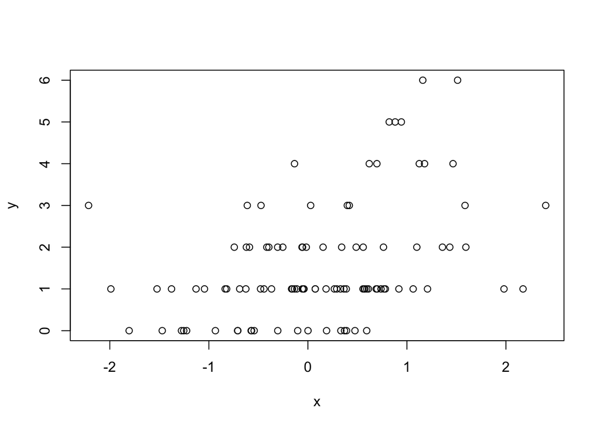

```r
plot(x,y)
```

#### Random Sampling

`sample` function draws randomly from vector of numbers

```r
set.seed(1)
#No replacement
sample(1:10,4)
```

```
## [1] 3 4 5 7
```

```r
sample(1:10,4)
```

```
## [1] 3 9 8 5
```

```r
sample(letters,5)
```

```
## [1] "q" "b" "e" "x" "p"
```

```r
sample(1:10) ## Permutation
```

```
##  [1]  4  7 10  6  9  2  8  3  1  5
```

```r
sample(1:10, replace = T) ## Smaple with replacement
```

```
##  [1] 2 3 4 1 4 9 4 5 6 5
```

#### Profiler

Useful for identifying bottleknecks and identifying slow points Other tools also help to optimize software. Don’t think about it at first. (Knuths Truths) Design first then optimize Collect data, don’t guess!

Using system.time() Returns time to evaluate expression in seconds two types of time:

- *User Time* = CPU Time
- *Elapsed Time* = “wall clock time”

Elapsed time can be greater if CPU spends a lot of time waiting around. Elapsed time can be shorter if you have multiple cores.

Using `Rprof()` The summaryRprof() function summarizes the output from `Rprof`

DO NOT USE `system.time()` and `Rprof` together.

Queries the call stack at a sampling interval (default 0.02 s)

Two methods of harnessing `summaryRprof`

- `by.total` total run time
- `by.self` subtracts out time below in the call stack.